# Regression

Anna Yeaton

Fall 2019

#Due Thursday Sept. 26th

# Lab Section

In this lab, we will go over regression. We will be using the caret package in R. https://topepo.github.io/caret/train-models-by-tag.html

# Perfomance Metrics

## Residual

Deviation of the observed value to the estimated value (sample mean)
$$residual=y_i - \hat{y_i}$$
where $\hat{y_i}$ is the estimated value

## Mean Squared Error (MSE)

$$MSE=\frac{1}{n}\sum_{i=1}^{n}(y_i - \hat{y_i})^2$$

## Root Mean Squared Error (RMSE)

Same units as original data.

$$RMSE=\sqrt{MSE}$$

## L2 regularization : Ridge regression. Regularize by adding the sum of the coefficients, squared, to the function.

$$Ridge Regression=\sum_{i=1}^{n}(y_i - w_0 - \sum_{j=1}^{p}w_jx_{ij})^2 + \lambda\sum_{j=1}^p(w_j)^2$$

## L1 regularization : Lasso Regression. Regularize by adding the sum of the absolute value of the coefficients to the model. Coefficient estimates may be pushed to zero – Lasso can perform variable selection

$$Lasso Regression=\sum_{i=1}^{n}(y_i - w_0 - \sum_{j=1}^{p}w_jx_{ij})^2 + \lambda\sum_{j=1}^p|w_j|$$

### The broad steps of Machine learning in R.

1. Split the data into training and test. Set test aside.
2. Fit a good model to the training data.
3. See how your model did on the training data.
4. Test how your model performs on the test data.

# Regression

1. Split data into training and test set (75% in train set, 25% in test set)

```r
set.seed(123)
smp_siz <- floor(0.75*nrow(airq))
part <- sample(seq(nrow(airq)),size = smp_siz)
train_regression <- airq[part,]
test_regression <- airq[-part,]
```

### Linear Regression

- Assumes a linear relationship.
- Independent variables should not be correlated (no mulitcollinearity)
- The number of observations should be greater than the number of independent variables.

$$RSS=\sum(y_i - \hat{y_i})^2$$
We will predict the response of the Temperature based on Wind.

This is the data we will fit a linear model to.

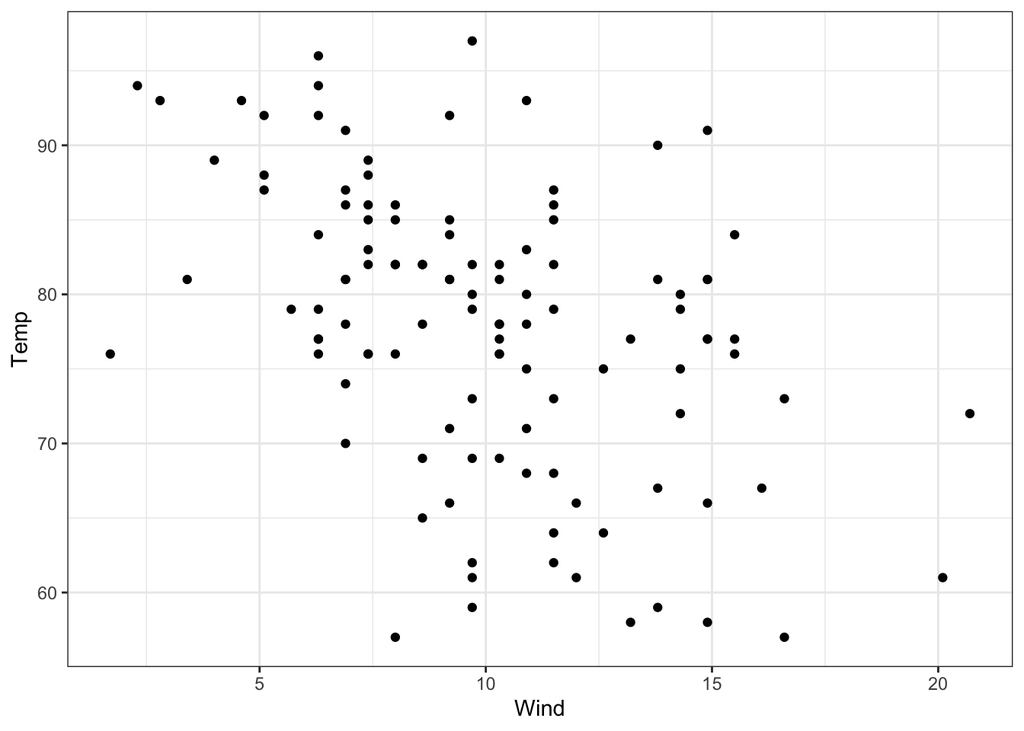

```r
ggplot(data = train_regression) +
  geom_point(aes(x=Wind, y=Temp)) +
  theme_bw()
```

2. Create and fit a linear model to predict Temperature from Wind using the training set

```r
#help(train)
#airq
#linear_regression <- train( ~ , data= , method = "lm")
linreg <- train(Temp ~ Wind, train_regression, method = "lm")
fit <- lm(airq$Temp ~ airq$Wind)
```

3. Vizualize how your model performed on the train data by plotting the regression line on top of the train data points.

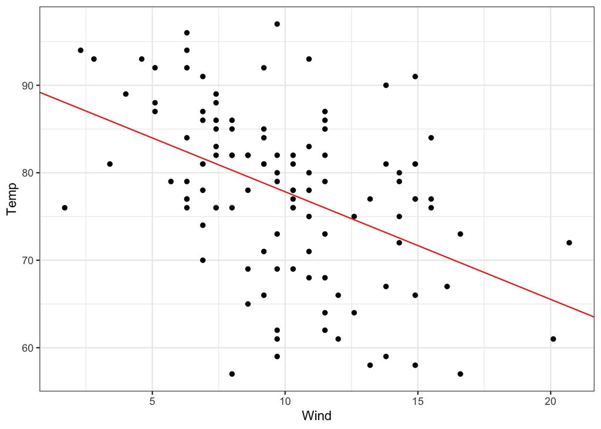

```r
#use the ggplot created in the previous chunk

ggplot(data = train_regression) +
  geom_point(aes(x=Wind, y=Temp)) +
  theme_bw()+
  geom_abline(slope = fit$coefficients[2], intercept = fit$coefficients[1], color = 'red')
```

```r
# plot(airq$Wind, airq$Temp, pch = 1)
# abline(fit$coefficients[1],fit$coefficients[2],col='red')
#
# plot(linreg$trainingData)
# abline(fit$coefficients[1], fit$coefficients[2], col = 'red')
#
# plot(train_regression$Temp)
# abline(fit$coefficients[1], fit$coefficients[2], col = 'red')
```

4. Explore how the model performs on the test data. For Linear Regression:
- The residuals should be close to zero.
- There should be equal variance around the regression line (homoscedasticity).
- Residuals should be normally distributed.
- Independent variables and residuals should not be correlated.